# act_report

ACT REPORT

This is the report of the project to show results of analysis and insights generated from the analysis and the visualisation. From the provided datasets, i was able to generate insight on : The most retweeted post(dog) The post(dog) with the highest favorite/like count the most popular and least popular breeds on the page

Therefore Harvey's post from 2018 has the highest retweets with 79515 retweet count and 131075 favorite/like count

Albus from 2017 has the highest favorite count with 132,810 favorite/like count and 48,265 retweet count

We can see that The golden retriever is the most popular breed with a sum of about 150 posts and the Australian terrier and sussex spaniel are the least posted with 2 posts each

Visualizations

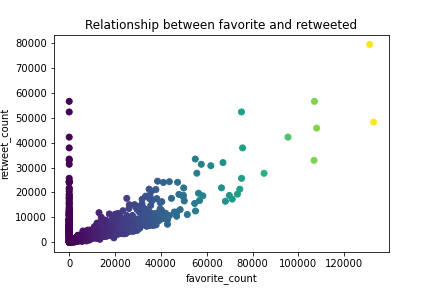

The above visualizations was done to represent the relationship between the favorite count/likes and retweet count of the posts. It can be concluded that there is a correlation between the likes and retweets.

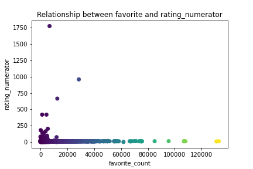

however, from the above visualization, we can notice that there's little or no relationship between the rating and the favorite/like count

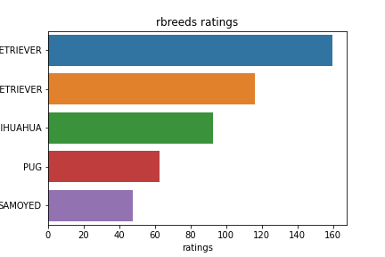

The golden retriever also has the highest likes and retweets and ratings too

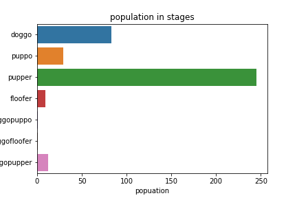

we can also conclude that the pupper stage has the highest number of dog_count